# CIFAR10

#### 神經網路

```python
import tensorflow as tf
from tensorflow import keras
import numpy as np
import matplotlib.pyplot as plt
```

##### 載入cifar10圖片

```python
(train_x, train_y), (test_x, test_y) = keras.datasets.cifar10.load_data()
```

##### 列印資料集shape

```python
print(train_x.shape)
print(train_y.shape)
print(test_x.shape)
print(test_y.shape)
```

```
(50000, 32, 32, 3)
(50000, 1)
(10000, 32, 32, 3)
(10000, 1)
```

##### 列印圖片

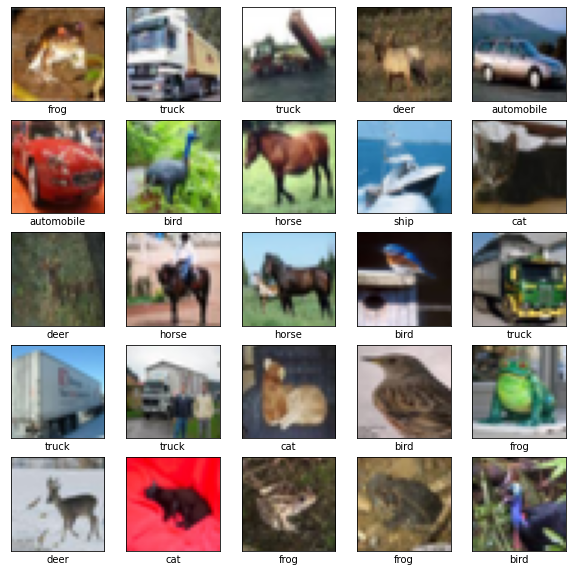

```python
class_names = ['airplane', 'automobile', 'bird', 'cat', 'deer',
               'dog', 'frog', 'horse', 'ship', 'truck']
plt.figure(figsize=(10, 10))
for i in range(25):
    plt.subplot(5, 5, i+1)
    plt.xticks([])
    plt.yticks([])
    plt.grid(False)
    plt.imshow(train_x[i])
    # The CIFAR labels happen to be arrays,
    # which is why you need the extra index
    plt.xlabel(class_names[train_y[i][0]])
plt.show()
```

##### 資料正規化

```python
train_x = train_x /255.0
test_x = test_x / 255.0
```

##### 搭建類神經網路

```
搭建一個輸入層，兩個隱藏層，分別２５６與１２８的節點，最後為節點為１０的輸出層
```

```python
model = keras.Sequential([
    keras.layers.Flatten(input_shape=(32, 32, 3)),
    keras.layers.Dense(256, activation='relu'),
    keras.layers.Dense(128, activation='relu'),
    keras.layers.Dense(10)
])

model.summary()
```

```
Model: "sequential"
_________________________________________________________________
Layer (type)                 Output Shape              Param #
=================================================================
flatten (Flatten)            (None, 3072)              0
_________________________________________________________________
dense (Dense)                (None, 256)               786688
_________________________________________________________________
dense_1 (Dense)              (None, 128)               32896
_________________________________________________________________
dense_2 (Dense)              (None, 10)                1290
=================================================================
Total params: 820,874
Trainable params: 820,874
Non-trainable params: 0
_________________________________________________________________
```

```python
model.compile(optimizer='adam',
              loss=tf.keras.losses.SparseCategoricalCrossentropy(from_logits=True),
              metrics=['accuracy'])
```

##### 訓練模型

```python
model.fit(train_x, train_y, epochs=10)
```

[output not shown]

```
<tensorflow.python.keras.callbacks.History at 0x205a8fa1240>
```

##### 計算模型準確度

```python
test_loss, test_acc = model.evaluate(test_x,  test_y, verbose=2)
print('Test accuracy:', test_acc)
```

[output not shown]

#### CNN模型

```python
from tensorflow.keras.models import Sequential
from tensorflow.keras.layers import Dense, Dropout, Flatten, Conv2D, MaxPooling2D
```

##### 載入cifar10圖片

```python
(train_x, train_y), (test_x, test_y) = keras.datasets.cifar10.load_data()
```

##### 資料正規化

```python
train_x = train_x /255.0
test_x = test_x / 255.0
```

##### 搭建CNN模型

[output not shown]

1. CNN 主要借助卷積層(Convolution Layer)的方法，將Input從原始的點陣圖，改為經過影像處理技術萃取的特徵，等於是提供更有效的資訊給模型使用，因此，預測的效果就會顯著的向上提升。厲害的是，我們也不用撰寫影像處理的程式碼，Neural Network(也許是框架?) 會幫我們自動找出這些特徵。
2. 卷積層是作Input的改善，所以，它通常會放在模型的『前』幾層，後面會緊跟著池化層，以簡化計算。
3. 最後，模型會回歸到全連接層(Dense)進行分類，卷積層是多維的陣列，全連接層的Input通常為一維，中間維度的轉換就靠『扁平層』(Flatten)來處理。
4. 為避免『過度擬合』(overfit)，我們會在特定的地方加上Dropout層，來防止過度擬合。

###### 卷積層(Convolution Layer)參數

Keras 提供的卷積層又分為幾個小類：

1. 一般性的：包括一維(Conv1D)、二維(Conv2D)、三維(Conv3D)，分別處理時序資料、2D 圖形及每一點含其他資訊的2D 圖形。
2. 裁切的(Cropping)：也包括一維(Conv1D)、二維(Conv2D)、三維(Conv3D)，可設定寬與高的上下左右各裁切N個點不使用。
3. 重複取樣(UpSampling)：也包括一維(Conv1D)、二維(Conv2D)、三維(Conv3D)，每一個區域重複取樣，與第一項相反，它是要作擴散樣本。

重要的參數說明如下：

1. Filters：濾波器數目，就是下圖的每一階段的輸出面數或是深度，輸出的圖稱為『特徵圖』(Feature Map)，通常是4的倍數。

[figure not shown]

2. kernel_size：卷積核大小，一般為正方形，邊長為奇數，便於尋找中心點。
3. strides：滑動步長，計算滑動視窗時移動的格數。
4. padding：補零方式，卷積層取週邊kernel_size的滑動視窗時，若超越邊界時，是否要放棄這個output點(valid)、一律補零(same)、還是不計算超越邊界的Input值(causal)。
5. data_format：channels_last (預設值) 或 channels_first，channels_last 是指通道資料放在最後一維，channels_first 是指通道資料放在第二維，因第一維為樣本數。
6. dilation_rate：膨脹比例，用於膨脹卷積，這個值設為非1的值，則strides必須等於1，反之亦然，因為兩個是互斥的，strides是縮小圖像，dilation_rate是膨脹圖像，兩者通常不會同時使用。
7. activation：要使用何種 activation function。

###### 池化層(Pooling Layer)參數

池化層(Pooling Layer) 又分為幾個小類：

1. 取最大值(Max)：包括一維(MaxPooling1D)、二維(MaxPooling2D)、三維(MaxPooling3D)，分別處理時序資料、2D 圖形及每一點含其他資訊的2D 圖形。
2. 取平均值(Average)：也包括一維(AveragePooling1D)、二維(AveragePooling2D)、三維(AveragePooling3D)。
3. 取全局最大值(GlobalMax)：包括一維(GlobalMaxPooling1D)、二維(MaxPooling2D)，分別處理時序資料、2D 圖形，不設池化尺寸(Pooling Size)，取全部 input 的最大值。

重要的參數說明如下：

1. pool_size：池化視窗的大小，通常設為2，效果就不錯。
2. strides：滑動步長，計算滑動視窗時移動的格數。
3. padding：補零方式，卷積層取週邊kernel_size的滑動視窗時，若超越邊界時，是否要放棄這個output點(valid)、還是一律補零(same)，沒有causal選項。
4. data_format：channels_last (預設值) 或 channels_first，channels_last 是指通道(色彩)資料放在最後一維，channels_first 是指通道資料放在第二維，因第一維為樣本數。

```python
model = Sequential()
model.add(Conv2D(32, (3, 3), activation='relu', input_shape=(32, 32, 3)))
model.add(MaxPooling2D((2, 2)))
model.add(Conv2D(64, (3, 3), activation='relu'))
model.add(MaxPooling2D((2, 2)))
model.add(Conv2D(64, (3, 3), activation='relu'))
model.add(MaxPooling2D((2, 2)))

model.add(Flatten())
model.add(Dense(128, activation='relu'))
model.add(Dense(10))

model.summary()
```

```
Model: "sequential_1"
_________________________________________________________________
Layer (type)                 Output Shape              Param #
=================================================================
conv2d (Conv2D)              (None, 30, 30, 32)        896
_________________________________________________________________
max_pooling2d (MaxPooling2D) (None, 15, 15, 32)        0
_________________________________________________________________
conv2d_1 (Conv2D)            (None, 13, 13, 64)        18496
_________________________________________________________________
max_pooling2d_1 (MaxPooling2 (None, 6, 6, 64)          0
_________________________________________________________________
conv2d_2 (Conv2D)            (None, 4, 4, 64)          36928
_________________________________________________________________
max_pooling2d_2 (MaxPooling2 (None, 2, 2, 64)          0
_________________________________________________________________
flatten_1 (Flatten)          (None, 256)               0
_________________________________________________________________
dense_3 (Dense)              (None, 128)               32896
_________________________________________________________________
dense_4 (Dense)              (None, 10)                1290
=================================================================
Total params: 90,506
Trainable params: 90,506
Non-trainable params: 0
_________________________________________________________________
```

```python
model.compile(optimizer='adam',
              loss=tf.keras.losses.SparseCategoricalCrossentropy(from_logits=True),
              metrics=['accuracy'])
```

##### 訓練模型

```python
hist = model.fit(train_x, train_y, epochs=25, validation_data=(test_x, test_y))
```

[output not shown]

##### 繪製圖表

```
將accuracy與epoch的關係以圖形化方式顯示出來
```

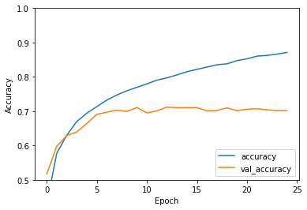

```python
plt.plot(hist.history['accuracy'], label='accuracy')
plt.plot(hist.history['val_accuracy'], label = 'val_accuracy')
plt.xlabel('Epoch')
plt.ylabel('Accuracy')
plt.ylim([0.5, 1])
plt.legend(loc='lower right')
```

##### 計算模型準確度

```python
test_loss, test_acc = model.evaluate(test_x,  test_y, verbose=2)
print(test_acc)
```

```
313/313 - 1s - loss: 1.1467 - accuracy: 0.7021
0.7020999789237976
```

#### Overfitting

##### 載入cifar10圖片

```python
(train_x, train_y), (test_x, test_y) = keras.datasets.cifar10.load_data()
```

##### 資料正規化

```python
train_x = train_x /255.0
test_x = test_x / 255.0
```

##### 搭建CNN模型 加入Dropout層

[figure not shown]

不管是在訓練機器學習或是深度學習的模型，想必都有遇過『Underfitting 』與『Overfitting』的狀況，而其中又以Overfitting最讓人頭疼。上圖給了我們一個很好的例子，左邊的圖描了Underfitting的狀況，中間的圖描述了良好的模型該有的劃分曲線，右邊的圖則是典型的Overfitting。

###### 欠擬合(Underfitting)

了解Overfitting前我們先來認識一下另一個常見的問題「Underfitting」，當我們在訓練一個模型時，發現不管是在訓練集或是測試集資料都無法達到一定的準度時，就可能是遇到Underfitting 的狀況。通常造成Underfitting的主要原因包含『訓練時間不足』、『模型複雜度不足』，而這兩種狀況都不難解決。在深度學習中，可以透過增加訓練迭代的次數來解決「訓練時間不足」的問題，透過調整神經元數量、模型深度、Kernel深度來解決「模型複雜度不足」的問題。如果上述調整仍然無法改善，可能就要考慮是訓練資料本身的問題。

###### 過擬合(Overfitting)

相較於Underfitting，Overfitting通常是讓我們更頭疼的問題，而在深度學習中我們該如何觀察Overfitting的狀況呢？下圖給了我們一個很好的例子，當隨個訓練的時間增長、迭代的次數增加，我們訓練集與測試集的Error都會逐步的下降，但當我們觀察到訓練集與測試集的Error開始分道揚鑣時，就可能是Ovefirring的狀況發生。

[figure not shown]

而造成Overfitting的主要原因包含：

1. 訓練資料不足

   > 訓練資料不足是大家最常會遇到的問題之一，當我們的訓練集太小時，模型找不到泛化的特徵，因此就頃向去硬記所擁有的資訊。
2. 迭代次數過多

   > 當我們不斷讓模型去學習訓練資料集時，到了最後模型就會試圖去硬背特徵，而大大降低了泛化能力。
3. 模型複雜度太高

   > 剛好與Underfitting相反，當我們使用一個很強的模型去學習時，模型較容易發生過擬合的狀況。

解決過擬合(Overfitting)

1. 訓練資料不足

   > 訓練資料不足的狀況，最直接的辦法就是區收集或爬取更多樣性的訓練資料，然而這往往是最困難的部分，如果是在Computer Vision領域，此時資料增強(Augmentation)就能派上用場，如果想對資料增強有更多理解，可以參考我們的上一篇: CNN入門-圖像增強。
2. 迭代次數過多

   > 針對迭代次數過多、訓練時間過長的問題，我們可以透過設置Early Stopping來解決，Early Stopping其實就是透過觀察測試資料集Loss的變化來停止訓練，並透過調整 patience決定容忍度，假如我們設置patience=10，也就是說當測試資料集的Loss在10個epoch後都沒有下降，此時就要停止訓練，而當然我們也可以客製化設置不同的Early Stopping，下方代碼為大家示範如何在Keras中設置Early Stopping，以及如何簡單手動設置Early Stopping。

   > ```
   > from keras.callbacks import EarlyStopping, ModelCheckpoint
   > earlystop = EarlyStopping(monitor='test_loss', patience=3, verbose=1)
   > classifier.fit(x_train,y_train,batch_size=100,epochs=100, validation_data = (x_test, y_test),callbacks = [earlystop])
   > ```

   > Early Stopping in Keras
3. Dropout

[figure not shown]

   > Dropout為Deepl Learning中常用的技巧，隨機關閉NN層中的一定比例神經元(讓其值為0)，藉此降低模型對各個神經元的依賴性。但過高比例的Dropout會影響模型的收斂，尤其是在Convolution層，所以大家使用上也要特別注意。
4. Regularizer

[figure not shown]

   > Regularizer不管是在ML/DL中都時常會被使用，其原理是在loss function後加上懲罰項，大家不要被數學式子嚇到了，我們可以這樣想像，model在收斂時，當model發現這個特徵比較有用時，最直接的作法就是提高這個特徵的權重，也就是上圖中的Wj，而為了避免model過度依賴這個特徵，我們就在Loss fuction上加上這個特徵的權重，當model試圖提高這個權重時，也會因此提高Loss，藉此抑制這個weigh的起伏。 Regularizer又可以分為L1(Lasso)、L2(Ridge)，通常來說我們會使用L2 Regularization，表現較穩定也比較不會造成權重歸0的狀況，而其中Lambda為超參數，太小起不了作用，太大則會影響模型收斂。

   > ```
   > from keras.models import Sequential
   > from keras.layers import Dense
   > from keras.layers import Dropout
   > from keras import regularizers
   > classifier=Sequential()
   > classifier.add(Dense(output_dim=100,activation='relu',kernel_regularizer=regularizers.l2(l=0.001)))##lambda為超參數
   > classifier.add(Dropout(p=0.5))
   > classifier.add(Dense(output_dim=100,activation='relu',kernel_regularizer=regularizers.l2(0.001)))
   > classifier.add(Dropout(p=0.3))
   > classifier.add(Dense(output_dim=30,activation='relu',kernel_regularizer=regularizers.l1(0.001)))
   > classifier.add(Dropout(p=0.3))
   > ```

5. Batch Normalization

[figure not shown]

   > 雖然Batch Normalization主要用途不是避免Overfitting，但其仍然能起到一定Regularize(正則)的作用，由於每次的mini-batch mean跟mini-batch variance都會不一樣，藉此影響到scale & shift參數的調整。

   > ```
   > from keras.models import Sequential
   > from keras.layers import Dense
   > from keras.layers import Dropout
   > from keras.layers import BatchNormalization
   > from keras import regularizers
   > classifier=Sequential()
   > classifier.add(Dense(output_dim=100,activation='relu',kernel_regularizer=regularizers.l2(l=0.001)))
   > classifier.add(BatchNormalization()) ##BatchNormalization
   > classifier.add(Dropout(p=0.5))
   > classifier.add(Dense(output_dim=100,activation='relu',kernel_regularizer=regularizers.l2(0.001)))
   > classifier.add(BatchNormalization())
   > classifier.add(Dropout(p=0.3))
   > ```

```python
model = Sequential()
model.add(Conv2D(filters=32,kernel_size=(3, 3),padding='same',input_shape=(32, 32, 3),activation='relu'))
model.add(Dropout(0.25))
model.add(MaxPooling2D(pool_size=(2, 2)))
model.add(Conv2D(filters=64, kernel_size=(3, 3), padding='same', activation='relu'))
model.add(Dropout(0.25))
model.add(MaxPooling2D(pool_size=(2, 2)))

model.add(Flatten())
model.add(Dropout(0.25))
model.add(Dense(1024, activation='relu'))
model.add(Dropout(0.25))
model.add(Dense(10, activation='softmax'))

model.summary()
```

```
Model: "sequential_2"
_________________________________________________________________
Layer (type)                 Output Shape              Param #
=================================================================
conv2d_3 (Conv2D)            (None, 32, 32, 32)        896
_________________________________________________________________
dropout (Dropout)            (None, 32, 32, 32)        0
_________________________________________________________________
max_pooling2d_3 (MaxPooling2 (None, 16, 16, 32)        0
_________________________________________________________________
conv2d_4 (Conv2D)            (None, 16, 16, 64)        18496
_________________________________________________________________
dropout_1 (Dropout)          (None, 16, 16, 64)        0
_________________________________________________________________
max_pooling2d_4 (MaxPooling2 (None, 8, 8, 64)          0
_________________________________________________________________
flatten_2 (Flatten)          (None, 4096)              0
_________________________________________________________________
dropout_2 (Dropout)          (None, 4096)              0
_________________________________________________________________
dense_5 (Dense)              (None, 1024)              4195328
_________________________________________________________________
dropout_3 (Dropout)          (None, 1024)              0
_________________________________________________________________
dense_6 (Dense)              (None, 10)                10250
=================================================================
Total params: 4,224,970
Trainable params: 4,224,970
Non-trainable params: 0
_________________________________________________________________
```

```python
model.compile(optimizer='adam',
              loss=tf.keras.losses.SparseCategoricalCrossentropy(from_logits=True),
              metrics=['accuracy'])
```

```python
hist = model.fit(train_x, train_y, epochs=25, validation_data=(test_x, test_y))
```

[output not shown]

##### 繪製圖表

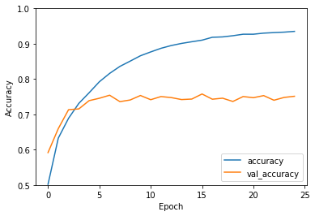

```python
plt.plot(hist.history['accuracy'], label='accuracy')
plt.plot(hist.history['val_accuracy'], label = 'val_accuracy')
plt.xlabel('Epoch')
plt.ylabel('Accuracy')
plt.ylim([0.5, 1])
plt.legend(loc='lower right')
```

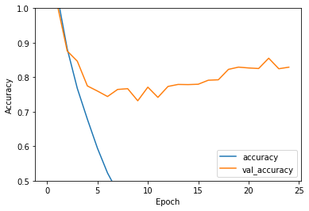

```python
plt.plot(hist.history['loss'], label='accuracy')
plt.plot(hist.history['val_loss'], label = 'val_accuracy')
plt.xlabel('Epoch')
plt.ylabel('Accuracy')
plt.ylim([0.5, 1])
plt.legend(loc='lower right')
```

```python
test_loss, test_acc = model.evaluate(test_x,  test_y, verbose=2)
print(test_acc)
```

```
313/313 - 2s - loss: 0.8291 - accuracy: 0.7512
0.7512000203132629
```